# Lesson 4 - Diamonds Project

# Loading the dataset

Load the diamonds data set in RStudio.

```r
library(ggplot2) #must load the ggplot package first
data(diamonds) #loads the diamonds data set since it comes with the ggplot package
```

You should notice that the diamonds data set will be listed as a ‘Promise’ in the workspace. This is a special object in R, and you need to run a command on the data to fully load the data set. Try running a summary:

```r
summary(diamonds)
```

```
##      carat               cut        color        clarity          depth
##  Min.   :0.2000   Fair     : 1610   D: 6775   SI1    :13065   Min.   :43.00
##  1st Qu.:0.4000   Good     : 4906   E: 9797   VS2    :12258   1st Qu.:61.00
##  Median :0.7000   Very Good:12082   F: 9542   SI2    : 9194   Median :61.80
##  Mean   :0.7979   Premium  :13791   G:11292   VS1    : 8171   Mean   :61.75
##  3rd Qu.:1.0400   Ideal    :21551   H: 8304   VVS2   : 5066   3rd Qu.:62.50
##  Max.   :5.0100                     I: 5422   VVS1   : 3655   Max.   :79.00
##                                     J: 2808   (Other): 2531
##      table           price             x                y
##  Min.   :43.00   Min.   :  326   Min.   : 0.000   Min.   : 0.000
##  1st Qu.:56.00   1st Qu.:  950   1st Qu.: 4.710   1st Qu.: 4.720
##  Median :57.00   Median : 2401   Median : 5.700   Median : 5.710
##  Mean   :57.46   Mean   : 3933   Mean   : 5.731   Mean   : 5.735
##  3rd Qu.:59.00   3rd Qu.: 5324   3rd Qu.: 6.540   3rd Qu.: 6.540
##  Max.   :95.00   Max.   :18823   Max.   :10.740   Max.   :58.900
##
##        z
##  Min.   : 0.000
##  1st Qu.: 2.910
##  Median : 3.530
##  Mean   : 3.539
##  3rd Qu.: 4.040
##  Max.   :31.800
##
```

You can learn more about the diamonds data set by executing the following code. The summary should appear in the help window (usually, it’s the lower right console).

```r
?diamonds
```

Read the help file to determine the best color for the diamonds data set. When you run diamonds$color, you will notice that the levels of color are set as D < E < F < …

This does not indicate that D is the worst color but rather an ordering to the colors.

# Question 1:

## (a) How many observations are in the dataset?

## (b) How many variables are in the data set?

## (c) How many ordered factors are in the data set?

## (d) What letter represents the best color for a diamond?

# Question #2:

Create a histogram of the price of all the diamonds in the diamond data set.

# Question #3:

Describe the shape and center of the price distribution. Include summary statistics like the mean and median.

# Question #4: Diamond Counts

1. How many diamonds cost less than $500?
2. How many diamonds cost less than $250?
3. How many diamonds cost $15,000 or more?

# Question #5:

Explore the largest peak in the price histogram you created earlier.

Try limiting the x-axis, altering the bin width, and setting different breaks on the x-axis.

You can save images by using the ggsave() command. ggsave() will save the last plot created. For example… qplot(x = price, data = diamonds) ggsave(‘priceHistogram.png’)

ggsave currently recognises the extensions eps/ps, tex (pictex), pdf, jpeg, tiff, png, bmp, svg and wmf (windows only).

# Question #6:

Break out the histogram of diamond prices by cut.

You should have five histograms in separate panels on your resulting plot.

# Question #7:

Answer the questions below. Check more than one option if there were ties.

Cut options: Fair, Good, Very Good, Premium, and Ideal

1. Which cut has the highest priced diamond?
2. Which cut has the lowest priced diamond?
3. Which cut has the lowest median price?

# Question #8:

In the two last exercises, we looked at the distribution for diamonds by cut.

Run the code below in R Studio to generate the histogram as a reminder.

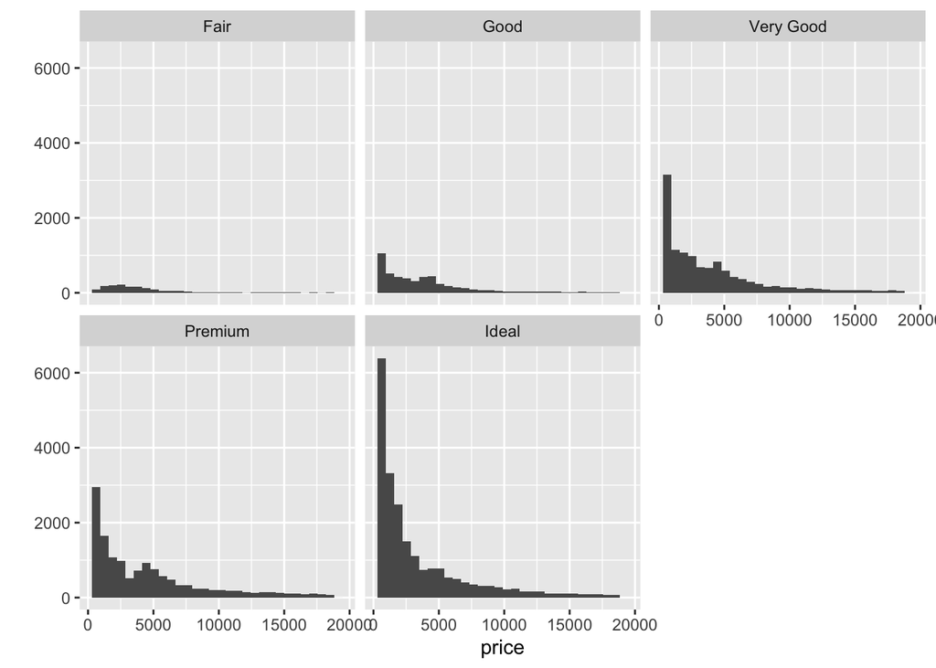

```r
qplot(x = price, data = diamonds) + facet_wrap(~cut)
```

In the last exercise, we looked at the summary statistics for diamond price by cut. If we look at the output table, the the median and quartiles are reasonably close to each other.

```r
by(diamonds$price, diamonds$cut, summary)
```

```
## diamonds$cut: Fair
##    Min. 1st Qu.  Median    Mean 3rd Qu.    Max.
##     337    2050    3282    4359    5206   18574
## ------------------------------------------------------------
## diamonds$cut: Good
##    Min. 1st Qu.  Median    Mean 3rd Qu.    Max.
##     327    1145    3050    3929    5028   18788
## ------------------------------------------------------------
## diamonds$cut: Very Good
##    Min. 1st Qu.  Median    Mean 3rd Qu.    Max.
##     336     912    2648    3982    5373   18818
## ------------------------------------------------------------
## diamonds$cut: Premium
##    Min. 1st Qu.  Median    Mean 3rd Qu.    Max.
##     326    1046    3185    4584    6296   18823
## ------------------------------------------------------------
## diamonds$cut: Ideal
##    Min. 1st Qu.  Median    Mean 3rd Qu.    Max.
##     326     878    1810    3458    4678   18806
```

This means the distributions should be somewhat similar, but the histograms we created don’t show that.

The ‘Fair’ and ‘Good’ diamonds appear to have different distributions compared to the better cut diamonds. They seem somewhat uniform on the left with long tails on the right.

Let’s look in to this more.

Look up the documentation for `facet_wrap` in R Studio. Then, scroll back up and add a parameter to facet_wrap so that the y-axis in the histograms is not fixed. You want the y-axis to be different for each histogram.

# Question #9:

Create a histogram of price per carat and facet it by cut. You can make adjustments to the code from the previous exercise to get started.

Adjust the bin width and transform the scale of the x-axis using log10.

# Question #10:

Investigate the price of diamonds using box plots, numerical summaries, and one of the following categorical variables: cut, clarity, or color.

There won’t be a solution video for this exercise so go to the discussion thread for either BOXPLOTS BY CLARITY, BOXPLOT BY COLOR, or BOXPLOTS BY CUT to share you thoughts and to see what other people found.

You can save images by using the ggsave() command. ggsave() will save the last plot created. For example… qplot(x = price, data = diamonds) ggsave(‘priceHistogram.png’)

ggsave currently recognises the extensions eps/ps, tex (pictex), pdf, jpeg, tiff, png, bmp, svg and wmf (windows only).